# Two Problems for Lab 3:

# Problem 1: Gender Recognition by Voice

From the description file at https://data.world/ml-research/gender-recognition-by-voice:

In order to analyze gender by voice and speech, a training database was required. A database was built using thousands of samples of male and female voices, each labeled by their gender of male or female. Voice samples were collected from the following resources:

- [The Harvard-Haskins Database of Regularly-Timed Speech](http://nsi.wegall.net/)
- Telecommunications & Signal Processing Laboratory (TSP) Speech Database at McGill University
- [VoxForge Speech Corpus](http://www.repository.voxforge1.org/downloads/SpeechCorpus/Trunk/Audio/Main/8kHz_16bit/)
- [Festvox CMU_ARCTIC Speech Database at Carnegie Mellon University](http://festvox.org/cmu_arctic/dbs_awb.html)

Each voice sample is stored as a .WAV file, which is then pre-processed for acoustic analysis using the specan function from the WarbleR R package. Specan measures 22 acoustic parameters on acoustic signals for which the start and end times are provided.

The output from the pre-processed WAV files were saved into a CSV file, containing 3168 rows and 21 columns (20 columns for each feature and one label column for the classification of male or female). You can download the pre-processed dataset in CSV format, using the link above Acoustic Properties Measured

The following acoustic properties of each voice are measured:

- **duration:** length of signal
- **meanfreq:** mean frequency (in kHz)
- **sd:** standard deviation of frequency
- **median:** median frequency (in kHz)
- **Q25:** first quantile (in kHz)
- **Q75:** third quantile (in kHz)
- **IQR:** interquantile range (in kHz)
- **skew:** skewness (see note in specprop description)
- **kurt:** kurtosis (see note in specprop description)
- **sp.ent:** spectral entropy
- **sfm:** spectral flatness
- **mode:** mode frequency
- **centroid:** frequency centroid (see specprop)
- **peakf:** peak frequency (frequency with highest energy)
- **meanfun:** average of fundamental frequency measured across acoustic signal
- **minfun:** minimum fundamental frequency measured across acoustic signal
- **maxfun:** maximum fundamental frequency measured across acoustic signal
- **meandom:** average of dominant frequency measured across acoustic signal
- **mindom:** minimum of dominant frequency measured across acoustic signal
- **maxdom:** maximum of dominant frequency measured across acoustic signal
- **dfrange:** range of dominant frequency measured across acoustic signal
- **modindx:** modulation index. Calculated as the accumulated absolute difference between adjacent measurements of fundamental frequencies divided by the frequency range

The gender of the speaker is given in the **label** column.

Note, the features for duration and peak frequency (peakf) were removed from training. Duration refers to the length of the recording, which for training, is cut off at 20 seconds. Peakf was omitted from calculation due to time and CPU constraints in calculating the value. In this case, all records will have the same value for duration (20) and peak frequency (0).

Load file using the code below.

#### Question 1:

Which two features are most indicative of gendered voice?

#### Question 2:

Preform Linear Regression, Logistic Regression, and Quadratic Discriminant Analysis on the features, graphing the resulting fits. How does the two feature fit compare to the fit on all features?

```python
### Libraries
import numpy as np
import pandas as pd
import matplotlib.pyplot as plt
from sklearn.preprocessing import LabelEncoder, StandardScaler
from sklearn.model_selection import train_test_split
import seaborn as sns
from sklearn.linear_model import LinearRegression
from sklearn.discriminant_analysis import QuadraticDiscriminantAnalysis
%pip install mlxtend
from mlxtend.feature_selection import SequentialFeatureSelector as sf
from sklearn.linear_model import LogisticRegression
from sklearn.discriminant_analysis import LinearDiscriminantAnalysis
```

Load data in and see info

```python
data = pd.read_csv("voice.csv")
data
data.info()
data.shape
```

```
<class 'pandas.core.frame.DataFrame'>
RangeIndex: 3168 entries, 0 to 3167
Data columns (total 21 columns):
 #   Column    Non-Null Count  Dtype
---  ------    --------------  -----
 0   meanfreq  3168 non-null   float64
 1   sd        3168 non-null   float64
 2   median    3168 non-null   float64
 3   Q25       3168 non-null   float64
 4   Q75       3168 non-null   float64
 5   IQR       3168 non-null   float64
 6   skew      3168 non-null   float64
 7   kurt      3168 non-null   float64
 8   sp.ent    3168 non-null   float64
 9   sfm       3168 non-null   float64
 10  mode      3168 non-null   float64
 11  centroid  3168 non-null   float64
 12  meanfun   3168 non-null   float64
 13  minfun    3168 non-null   float64
 14  maxfun    3168 non-null   float64
 15  meandom   3168 non-null   float64
 16  mindom    3168 non-null   float64
 17  maxdom    3168 non-null   float64
 18  dfrange   3168 non-null   float64
 19  modindx   3168 non-null   float64
 20  label     3168 non-null   object
dtypes: float64(20), object(1)
memory usage: 519.9+ KB
```

```
(3168, 21)
```

```python
label_encoder = LabelEncoder()
data['label'] = label_encoder.fit_transform(data['label'])
dict(enumerate(label_encoder.classes_))
###{0: 'female', 1: 'male'}
```

```
{0: 'female', 1: 'male'}
```

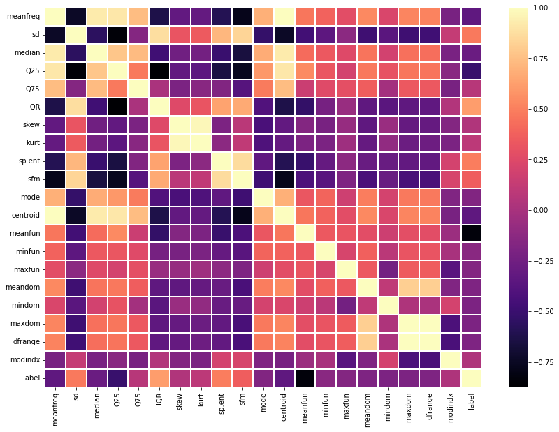

```python
fig,ax = plt.subplots(figsize=(14, 10))
sns.heatmap(data.corr(), ax=ax, linewidths=0.1,cmap="magma")
plt.show()
```

Boxplot, Violinplot, Swarmplot

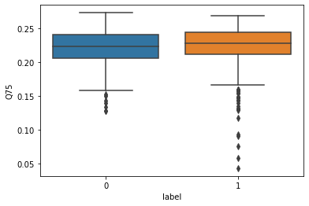

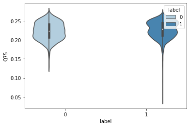

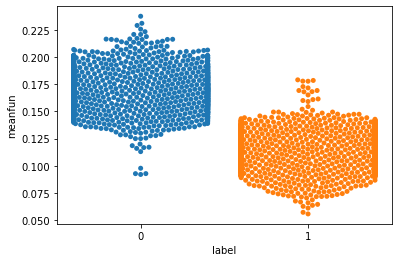

```python
sns.boxplot(data=data, x="label", y = 'Q75')
plt.show()
sns.violinplot(x="label", y="Q75", hue="label", data=data, palette="Blues")
plt.show()
sns.swarmplot(data=data, x="label", y="meanfun")
plt.show()
```

Features:

```python
featureSelector = sfs(
                    LinearRegression(),
                    k_features=2,
                    forward=True,
                    floating=False,
                    verbose=2,
                    scoring='r2',
                    cv=5
                    )

featureSelector.fit(data.drop(['label'], axis=1), data.label)
featureSelector.k_score_ , featureSelector.k_feature_names_
```

```
[Parallel(n_jobs=1)]: Using backend SequentialBackend with 1 concurrent workers.
[Parallel(n_jobs=1)]: Done   1 out of   1 | elapsed:    0.0s remaining:    0.0s
[Parallel(n_jobs=1)]: Done  20 out of  20 | elapsed:    0.3s finished

[2022-11-16 01:59:12] Features: 1/2 -- score: 0.134759583302476[Parallel(n_jobs=1)]: Using backend SequentialBackend with 1 concurrent workers.
[Parallel(n_jobs=1)]: Done   1 out of   1 | elapsed:    0.0s remaining:    0.0s
[Parallel(n_jobs=1)]: Done  19 out of  19 | elapsed:    0.2s finished

[2022-11-16 01:59:12] Features: 2/2 -- score: 0.1477310363894818
```

```
(0.1477310363894818, ('Q75', 'meanfun'))
```

most predictive features: 'Q75' 'meanfun'

```python
x = data.iloc[:,:-1]
y = data.label
x_train, x_test,y_train,y_test = train_test_split(x,y,test_size=0.2)
```

All features LR, Linear, QDA

Linear Regression

```python
model = LinearRegression()
model.fit(x_train,y_train)
y_1 = model.predict(x_test)
print('Linear Regression: ',model.score(x_test,y_test))
```

```
Linear Regression:  0.810242170348423
```

Logistic Regression

```python
LRmodel = LogisticRegression(max_iter=10000)
LRmodel.fit(x_train,y_train)
y_2 = LRmodel.predict(x_test)
print('Logistic Regression: ',LRmodel.score(x_test,y_test))
```

```
Logistic Regression:  0.9085173501577287
```

Quadratic Discriminant Analysis

```python
modelQDA = QuadraticDiscriminantAnalysis()
modelQDA.fit(x_train,y_train)
y_3 = modelQDA.predict(x_test)
print('QDA model: ',modelQDA.score(x_test,y_test))
```

```
QDA model:  0.7160883280757098
```

Two features

```python
x_new = data[['Q75','meanfun']]
y_new = data.label
x_train_new, x_test_new,y_train_new,y_test_new = train_test_split(x_new,y_new,test_size=0.2)
```

Linear Regression

```python
model_new = LinearRegression()
model_new.fit(x_train_new,y_train_new)
y1 = model_new.predict(x_test_new)
print('Linear Regression: ',model_new.score(x_test_new,y_test_new))
```

```
Linear Regression:  0.7242444038518744
```

Graph it

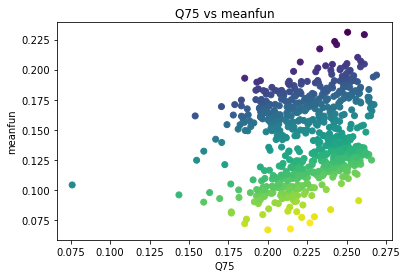

```python
plt.scatter(x_test_new["Q75"], x_test_new["meanfun"], c=model_new.predict(x_test_new))
plt.title("Q75 vs meanfun")
plt.xlabel("Q75")
plt.ylabel("meanfun")
plt.show()
```

Logistic Regression

```python
LRmodel_new = LogisticRegression(max_iter=10000)
LRmodel_new.fit(x_train_new,y_train_new)
y2 = LRmodel_new.predict(x_test_new)
print('Logistic Regression: ',LRmodel_new.score(x_test_new,y_test_new))
```

```
Logistic Regression:  0.9574132492113565
```

Graph

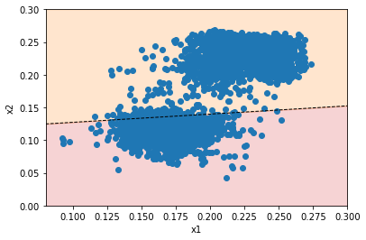

```python
xmin, xmax = 0.08, 0.3
ymin, ymax = 0, 0.3
b = LRmodel_new.intercept_[0]
w1, w2 = LRmodel_new.coef_.T
xc = np.array([xmin, xmax])
yc = (-w1/w2)*xc + (-b/w2)
plt.plot(xc, yc, 'k', lw=1, ls='--')
plt.fill_between(xc, yc, ymin, color='tab:red', alpha=0.2)
plt.fill_between(xc, yc, ymax, color='tab:orange', alpha=0.2)
plt.scatter(x_new[y_new == 0],x_new[y_new == 1])
plt.xlim(xmin, xmax)
plt.ylim(ymin, ymax)
plt.ylabel('x2')
plt.xlabel('x1')
plt.show()
```

Quadratic Discriminant Analysis

```python
modelQDA_new = QuadraticDiscriminantAnalysis()
modelQDA_new.fit(x_train_new,y_train_new)
y3 = modelQDA_new.predict(x_test_new)
print('QDA model : ',modelQDA_new.score(x_test_new,y_test_new))
```

```
QDA model :  0.9542586750788643
```

Graph

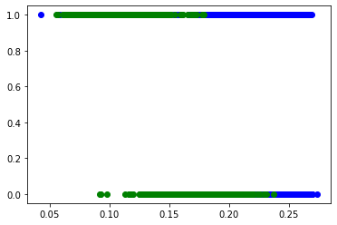

```python
from matplotlib import pyplot as plt
plt.scatter(x_new["Q75"],y_new,color='blue')
plt.scatter(x_new["meanfun"],y_new,color='green')
plt.show()
```

```python
###All Features--
print('linear regression:', model.score(x_test,y_test))
print('logistic regression:', LRmodel.score(x_test,y_test))
print('QDA:', modelQDA.score(x_test,y_test))

###Two Features:
print('linear regression:', model_new.score(x_test_new,y_test_new))
print('logistic regression:', LRmodel_new.score(x_test_new,y_test_new))
print('QDA:', modelQDA_new.score(x_test_new,y_test_new))

###Compare the values. Bigger number means it performed better

####Two features is better in Logistic and QDA, but not Linear
```

```
linear regression: 0.810242170348423
logistic regression: 0.9085173501577287
QDA: 0.7160883280757098
linear regression: 0.7242444038518744
logistic regression: 0.9574132492113565
QDA: 0.9542586750788643
```

# Problem 2: MRI Data

The dementia level (CDR) for the Oasis 1 MRI dataset is based on a patient assessment. As a result, it is not clear whether the levels of 0, .5, 1 and 2 should actually be understood as meaningfully numeric, or if they in fact are categorical labels.

**Note:** It is very import that we perform the train test split *before* we expand the dataset through down sampling. If not, we are effectively training on the test data.

```python
file_dir = 'C:/python/ML Lab2/MRI_Images/MRI_Images/'
labels = pd.read_csv(file_dir + 'labels.csv')
display(labels)
y = labels.CDR
from sklearn.model_selection import train_test_split
```

|  | Unnamed: 0 | Filename | ID | M/F | Hand | Age | Educ | SES | MMSE | CDR | eTIV | nWBV | ASF | Delay | Slice |
| --- | --- | --- | --- | --- | --- | --- | --- | --- | --- | --- | --- | --- | --- | --- | --- |
| 0 | 0 | OAS1_0001_MR1_55.png | OAS1_0001_MR1 | F | R | 74 | 2 | 3.0 | 29 | 0.0 | 1344 | 0.743 | 1.306 | NaN | 55 |
| 1 | 1 | OAS1_0001_MR1_120.png | OAS1_0001_MR1 | F | R | 74 | 2 | 3.0 | 29 | 0.0 | 1344 | 0.743 | 1.306 | NaN | 120 |
| 2 | 2 | OAS1_0001_MR1_180.png | OAS1_0001_MR1 | F | R | 74 | 2 | 3.0 | 29 | 0.0 | 1344 | 0.743 | 1.306 | NaN | 180 |
| 3 | 3 | OAS1_0002_MR1_55.png | OAS1_0002_MR1 | F | R | 55 | 4 | 1.0 | 29 | 0.0 | 1147 | 0.810 | 1.531 | NaN | 55 |
| 4 | 4 | OAS1_0002_MR1_120.png | OAS1_0002_MR1 | F | R | 55 | 4 | 1.0 | 29 | 0.0 | 1147 | 0.810 | 1.531 | NaN | 120 |
| ... | ... | ... | ... | ... | ... | ... | ... | ... | ... | ... | ... | ... | ... | ... | ... |
| 604 | 604 | OAS1_0449_MR1_120.png | OAS1_0449_MR1 | F | R | 71 | 3 | 4.0 | 29 | 0.0 | 1264 | 0.818 | 1.388 | NaN | 120 |
| 605 | 605 | OAS1_0449_MR1_180.png | OAS1_0449_MR1 | F | R | 71 | 3 | 4.0 | 29 | 0.0 | 1264 | 0.818 | 1.388 | NaN | 180 |
| 606 | 606 | OAS1_0456_MR1_55.png | OAS1_0456_MR1 | M | R | 61 | 5 | 2.0 | 30 | 0.0 | 1637 | 0.780 | 1.072 | NaN | 55 |
| 607 | 607 | OAS1_0456_MR1_120.png | OAS1_0456_MR1 | M | R | 61 | 5 | 2.0 | 30 | 0.0 | 1637 | 0.780 | 1.072 | NaN | 120 |
| 608 | 608 | OAS1_0456_MR1_180.png | OAS1_0456_MR1 | M | R | 61 | 5 | 2.0 | 30 | 0.0 | 1637 | 0.780 | 1.072 | NaN | 180 |

609 rows × 15 columns

```python
data = np.zeros([609, 30976])

for n, file_name in enumerate(labels.Filename):
    data[n,:] = np.mean(matplotlib.image.imread(file_dir + file_name),axis=2).reshape(-1)

X_train, X_test, y_train, y_test = train_test_split(data, y, test_size=0.2, random_state=0)
print(y_train.shape, y_test.shape)
```

```
(487,) (122,)
```

We want to sample the data array using the `data[start:stop:step]` slice paradigm. This means we are taking elements of the array `data` starting at `start`, ending at `stop` with step `step`. This is why previously `data[::DS]` down sampled at a rate of DS. For example,

```
lst = list(range(165)); lst[6::10]
```

returns

```
[6, 16, 26, 36, 46, 56, 66, 76, 86, 96, 106, 116, 126, 136, 146, 156]
```

`Xds_train[n+i, :] = X_train[i::DS]`

This will split our images into DS down sampled images. We then need to be sure to save out the appropriate label:

```python
DS = 8             # Downsample rate, must be a multiple of 30976

N_train = y_train.shape[0]  # The length of the training data

if 30976/DS % 1 > 0:
    print("Downsample rate is not a multiple of 30976")
    DS = 1
    im_size = 30976
else:
    im_size = int(30976/DS)

Xds_train = np.zeros([N_train*DS, im_size])
yds_train = np.zeros([N_train*DS, im_size])

for n in range(N_train):
    for i in range(DS):
        Xds_train[n+i,:] = X_train[n,i::DS]
        yds_train[n+i] = y[n]

print(Xds_train.shape)
```

```
(3896, 3872)
```

```python
N_train*DS
```

```
3896
```

```python
N_train
```

```
487
```

### Question 1:

Based on the code above, downsample the test data in the same way. ()

```python
DS = 8             # Downsample rate, must be a multiple of 30976

N_test = y_test.shape[0]  # The length of the test data

if 30976/DS % 1 > 0:
    print("Downsample rate is not a multiple of 30976")
    DS = 1
    im_size = 30976
else:
    im_size = int(30976/DS)

Xds_test = np.zeros([N_test*DS, im_size])
yds_test = np.zeros([N_test*DS, im_size])

for n in range(N_test):
    for i in range(DS):
        Xds_test[n+i,:] = X_test[n,i::DS]
        yds_test[n+i] = y[n]

print(Xds_test.shape)
```

```
(976, 3872)
```

```python
y.value_counts()
y_train = pd.get_dummies(y_train)
y_test = pd.get_dummies(y_test)

y_train = y_train.iloc[:, 0]
y_test = y_test.iloc[:, 0]
N_test*DS
N_test
```

```
122
```

### Question 2:

Perform LDA, QDA, Logistic Regression and Categorical Linear Regression on the down sampled Oasis 1 dataset. How do these compare to linear regression?

LDA, QDA, Logistic Regression and Categorical Linear Regression (Just plug in code)

```python
modelLDA = LinearDiscriminantAnalysis()
modelLDA.fit(X_train,y_train)
y_12 = modelLDA.predict(X_test)
print( 'LDA model : ',modelLDA.score(X_test,y_test))

modelQDA = QuadraticDiscriminantAnalysis()
modelQDA.fit(X_train,y_train)
y_22 = modelQDA.predict(X_test)
print('QDA model : ',modelQDA.score(X_test,y_test))

modelLog = LogisticRegression()
modelLog.fit(X_train,y_train)
y_32 = modelLog.predict(X_test)
print('Logistic Regression model : ',modelLog.score(X_test,y_test))

modelLR = LinearRegression()
modelLR.fit(X_train,y_train)
y_42 = modelLR.predict(X_test)
print('Linear Regression model : ',modelLR.score(X_test,y_test))
```

```
LDA model :  0.5819672131147541
```

```
QDA model :  0.5
```

```
Logistic Regression model :  0.5327868852459017
Linear Regression model :  -0.30072120583385553
```

Other models are better than Linear